# Modeling preference heterogeneity

The probit model assigns alternative $j$ at occasion $t$ of decider $n$ the latent utility $U_{ntj} = X_{ntj}^\top \beta_n + \epsilon_{ntj}$ with the coefficient vector $\beta_n$. A model with fixed coefficients sets $\beta_n = \beta$ for all deciders and thereby assumes that all deciders weigh price, time, and comfort in the same way. This is rarely true: some travelers react mainly to the fare, others to travel time, and some households would pay a premium for a local electricity supplier while others would not. **RprobitB** lets coefficients differ between deciders in two ways, which can be combined: random coefficients follow a continuous distribution over the population, and latent classes divide the deciders into groups. Both are requested through arguments of `fit()`. Oelschläger (2026) treats the methodological background. Random coefficients and latent classes are first estimated on simulated data, where the estimates can be compared with the parameters that generated them, and then applied to data of the **mlogit** package (Croissant 2020).

```r
library(RprobitB)
set.seed(1)
```

## Random coefficients

Each term named in `random_effects` receives a separate coefficient for every decider, drawn from a population distribution whose parameters the sampler estimates together with the other parameters. Such hierarchical models capture continuous preference heterogeneity and allow inference about the coefficients of individual deciders (Allenby and Rossi 1998). The population distribution is normal on a latent scale: the random coefficients of decider $n$ are $\beta_n \sim \mathrm{N}(\mu, \Omega)$ with the mean vector $\mu$ and the covariance matrix $\Omega$, reported as `mu[<effect>]` and `Omega[<effect>,<effect>]`. The mixing distribution of an effect decides how its latent normal variable enters the utility. An unnamed vector requests correlated normal effects. A named vector selects the mixing distribution of each term as `"<covariate>" = "<distribution>"`, where `"ASC"` names the alternative-specific constants:

| Value | Distribution | Coefficient |
| --- | --- | --- |
| `"cn"` | correlated normal | any sign |
| `"n"` | uncorrelated normal | any sign |
| `"cln"` | correlated log-normal | positive |
| `"ln"` | uncorrelated log-normal | positive |
| `"cln-"` | correlated log-normal | negative |
| `"ln-"` | uncorrelated log-normal | negative |

The six values combine two choices. The first is the shape of the distribution. A normal coefficient can take any value, which suits an attribute that some deciders like and others dislike. A log-normal coefficient is the exponential of a normal variable and therefore always positive, or, with the trailing minus, always negative. It suits an attribute whose sign is fixed by theory: a higher price is not expected to raise the utility of any decider. Log-normal effects are estimated on the latent normal scale, so `mu`, `Omega`, and the individual draws refer to the normal variable whose exponential enters the utility. The second choice is whether an effect is correlated with the other correlated effects. Deciders who value travel time may also value comfort, and the `c` prefix adds the covariance between such effects to the model. An uncorrelated effect has its own variance but no covariance with any other effect, which appears as zeros in `Omega`.

The following demonstration combines both choices. The price coefficient is negative log-normal and uncorrelated. Travel time and comfort receive correlated normal effects with a positive covariance.

```r
mixing <- fit(
  choice ~ price + time + comfort | 0,
  random_effects = c(price = "ln-", time = "cn", comfort = "cn"),
  n_deciders = 100,
  n_occasions = 10,
  dgp_parameters = list(
    beta = c(price = -1, time = -0.8, comfort = 0.5),
    Omega = rbind(c(0.25, 0, 0), c(0, 0.4, 0.2), c(0, 0.2, 0.3))
  ),
  iterations = 4000,
  warmup = 2000,
  thin = 2,
  chains = 1,
  save_individual_draws = TRUE
)
summary(mixing)
```

```
#> Bayesian probit choice model
#> Formula: choice ~ price + time + comfort | 0 | 0
#> Samples: 1000 retained per chain, 1 chain
#>                variable   dgp   mean   mode     sd rhat ess_bulk
#>               mu[price] -1.00 -0.967 -0.861 0.1761 1.02    16.78
#>                mu[time] -0.80 -0.874 -0.873 0.0972 1.05    29.15
#>             mu[comfort]  0.50  0.554  0.555 0.0814 1.00    69.99
#>      Omega[price,price]  0.25  0.311  0.181 0.1681 1.01    16.78
#>        Omega[time,time]  0.40  0.453  0.402 0.1434 1.17     6.19
#>     Omega[time,comfort]  0.20  0.260  0.236 0.0846 1.02    37.34
#>  Omega[comfort,comfort]  0.30  0.344  0.327 0.0961 1.02    43.95
```

The `dgp` column lists the parameters that generated the data. For the price coefficient, `mu[price]` is the mean of the latent normal variable, so the coefficient that enters the utility is minus its exponential and negative for every decider. `time` and `comfort` share the estimated covariance `Omega[time,comfort]`, while `price` has no covariance entry with either of them.

The mixing distribution of an effect is the distribution of its coefficient in the population. `plot(type = "mixture")` draws its estimate, the density that `mu` and `Omega` imply, averaged over the retained draws. For simulated data, dashed lines add the mixing distributions that generated them:

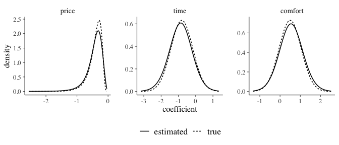

```r
plot(mixing, type = "mixture")
```

`interpret()` converts the coefficients into trade-offs. For a random effect it uses the coefficient of the median decider, which for the log-normal price is minus the exponential of `mu[price]`:

```r
interpret(mixing, reference = "price")
```

```
#> 1 `time` compensates -2.33 `price` (95% interval -3.57 to -1.62)
#> 1 `comfort` compensates 1.48 `price` (95% interval 0.965 to 2.21)
```

The `dgp_parameters` set the latent mean of the price effect to `-1`, so the true median price coefficient is `-exp(-1)`, about `-0.37`. Dividing the negated true time and comfort coefficients by it gives the true trade-offs, with which the posterior means above can be compared.

The panel structure makes individual coefficients estimable. `coef(level = "individual")` returns the posterior mean coefficient of every decider, on the latent normal scale for log-normal effects. The histogram shows the price coefficient of each of the 100 deciders, all negative as the log-normal specification enforces, with the left tail containing the deciders who react most strongly to a higher price.

```r
individual <- coef(mixing, level = "individual")
head(individual)
```

```
#>        price        time    comfort
#> 1 -1.0200039 -0.67214338  0.8740841
#> 2 -1.2903525 -1.34756825 -0.3577251
#> 3 -0.8659240 -0.25212699  0.8996742
#> 4 -0.8699187 -0.28498525  1.2180794
#> 5 -0.7378405  0.03161872  1.1608198
#> 6 -1.1649809 -1.76361959 -0.3922436
```

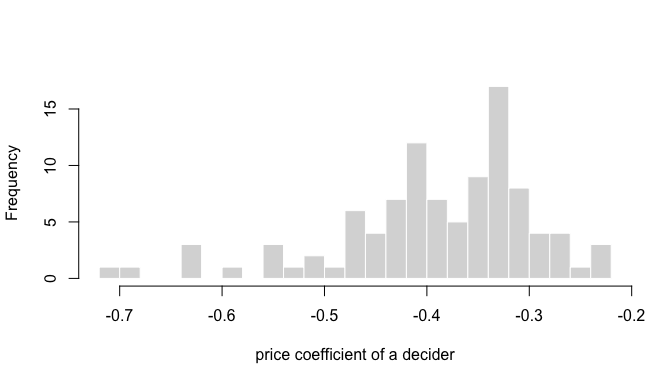

```r
price <- -exp(individual[, "price"])
hist(
  price,
  breaks = 30, col = "grey85", border = "white",
  main = "", xlab = "price coefficient of a decider"
)
```

### Willingness to pay for electricity supplier attributes

The `Electricity` data of the **mlogit** package come from a stated choice experiment in which 361 US households chose 8 to 12 times among four hypothetical suppliers. The suppliers differ in price (`pf`), contract length (`cl`), whether the supplier is local (`loc`) or well-known (`wk`), and whether it offers time-of-day (`tod`) or seasonal (`seas`) rates (Huber and Train 2001). The attribute columns end in the supplier number without a delimiter, `pf1` to `pf4`, so an underscore is inserted first, and the choice occasions of a household are numbered in the order of the rows.

Contract length and locality receive correlated normal random coefficients, the other attributes one coefficient for all households. Fixing the price coefficient to `-1` identifies the scale and expresses every other coefficient in cents per kWh, that is, directly as a willingness to pay. The fit uses the first 100 households to keep the computation short.

```r
data("Electricity", package = "mlogit")
names(Electricity) <- sub("([a-z]+)([1-4])$", "\\1_\\2", names(Electricity))
Electricity$occasion <- ave(Electricity$id, Electricity$id, FUN = seq_along)
households <- Electricity[Electricity$id %in% unique(Electricity$id)[1:100], ]
electricity <- fit(
  choice ~ pf + cl + loc + wk + tod + seas | 0,
  data = households,
  random_effects = c("cl", "loc"),
  column_decider = "id",
  column_occasion = "occasion",
  scale = c(pf = -1),
  iterations = 4000,
  warmup = 2000,
  thin = 2,
  chains = 1,
  save_individual_draws = TRUE,
  progress = FALSE
)
summary(electricity)
```

```
#> Bayesian probit choice model
#> Formula: choice ~ pf + cl + loc + wk + tod + seas | 0 | 0
#> Samples: 1000 retained per chain, 1 chain
#>        variable    mean    mode     sd  rhat ess_bulk
#>        beta[wk]  1.6238  1.5800 0.1386 0.999    263.7
#>       beta[tod] -8.9980 -9.0139 0.1706 1.015     77.1
#>      beta[seas] -9.2542 -9.2345 0.1474 1.005    233.1
#>          mu[cl] -0.2809 -0.2700 0.0638 1.001    458.0
#>         mu[loc]  2.0072  1.9804 0.2451 1.001    410.0
#>    Omega[cl,cl]  0.2974  0.2980 0.0678 1.001    205.8
#>   Omega[cl,loc]  0.0983  0.0808 0.1215 1.016    167.1
#>  Omega[loc,loc]  2.3143  2.0882 0.6483 1.000    172.9
#>      Sigma[2,2]  7.5847  7.5664 1.6043 1.043     30.6
#>      Sigma[2,3]  2.1155  1.9360 1.0364 1.095     10.3
#>      Sigma[3,3]  5.2820  5.0504 1.1639 1.021     98.5
#>      Sigma[2,4]  4.1002  3.9978 1.1204 1.015     49.8
#>      Sigma[3,4]  1.7735  1.6184 0.8074 1.042     29.5
#>      Sigma[4,4]  6.3354  5.5194 1.5176 1.054     38.2
```

Because the price coefficient is fixed, `interpret()` reports the coefficients directly as willingness to pay in cents per kWh, with credible intervals:

```r
interpret(electricity, effects = c("cl", "loc", "wk"))
```

```
#> 1 `cl` compensates -0.281 `pf` (95% interval -0.404 to -0.163)
#> 1 `loc` compensates 2.01 `pf` (95% interval 1.56 to 2.52)
#> 1 `wk` compensates 1.62 `pf` (95% interval 1.37 to 1.91)
```

On average, households would accept a price about 2 cents per kWh higher for a local supplier, and would need a price about 0.28 cents lower for each additional year of contract length.

The estimated mixing distributions show how these valuations vary between households:

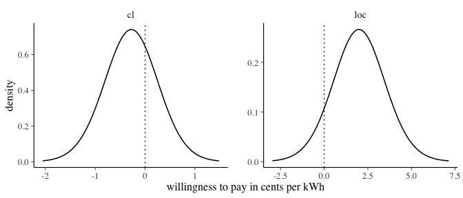

```r
plot(electricity, type = "mixture") +
  ggplot2::geom_vline(xintercept = 0, linetype = "dotted") +
  ggplot2::labs(x = "willingness to pay in cents per kWh")
```

```r
draws <- posterior::as_draws_matrix(electricity)
longer <- mean(pnorm(
  0, draws[, "mu[cl]"], sqrt(draws[, "Omega[cl,cl]"]), lower.tail = FALSE
))
distant <- mean(pnorm(0, draws[, "mu[loc]"], sqrt(draws[, "Omega[loc,loc]"])))
```

Although the average household prefers shorter contracts, the estimated mixing distribution assigns a positive valuation of contract length to about 30 percent of the households, and about 9 percent prefer a supplier that is not local.

## Latent classes

A single normal distribution is a strong assumption about the distribution of preferences in a population. There may be commuters and leisure travelers, or households that focus on price and households that focus on service. `latent_class_effects` names the effects that differ between `classes` latent classes. Every decider belongs to exactly one class. The class weights $w_1, \dots, w_K$ are the probabilities of membership and sum to one, and the class allocation of every decider is a latent variable that the sampler draws together with the parameters. Naming a random effect in `latent_class_effects` replaces its normal distribution by a finite mixture of normals, which yields the latent-class mixed multinomial probit model of Oelschläger and Bauer (2021). Random effects that are not named keep one distribution for all deciders, and a named coefficient that is not random takes one value per class and does not vary within it, as in the classical latent class model (Kamakura and Russell 1989; Greene and Hensher 2003). `class_update` selects how the number of classes is treated:

- `class_update = "fixed"` when exactly $K$ substantively meaningful classes are assumed;
- `class_update = "sparse"` when `classes` is a generous upper bound and redundant classes should empty;
- `class_update = "dirichlet_process"` for a Dirichlet-process mixture whose number of occupied classes is itself random;
- `class_update = "weight_based"` for the split, remove, and merge heuristic.

All four updates are demonstrated on one simulated data set with two classes. The fixed-class fit simulates the data; the other three are refits through `update()`, which reuses the simulated data.

### A fixed number of classes

For `class_update = "fixed"`, `classes = K` fixes the number of classes. The class weights have the prior $(w_1,\ldots,w_K)\sim\operatorname{Dirichlet}(\delta,\ldots,\delta)$, where the default `class_concentration = 1` is uniform on the weight simplex. The class labels are arbitrary: swapping them leaves the likelihood unchanged, so the sampler may swap them during a run. **RprobitB** therefore relabels the retained draws after sampling, so that every draw uses the same labels (Dahl 2006; Papastamoulis and Iliopoulos 2010), and numbers the classes by decreasing weight.

The following demonstration uses eight occasions per decider and two well-separated classes: a majority with coefficients centered at `-1` and a minority centered at `2`.

```r
mixture <- fit(
  choice ~ x | 0,
  random_effects = "x",
  latent_class_effects = "x",
  classes = 2,
  n_deciders = 100,
  n_occasions = 8,
  save_individual_draws = TRUE,
  dgp_parameters = list(
    beta = list(c(x = -1), c(x = 2)),
    Omega = list(matrix(0.2), matrix(0.2)),
    weights = c(0.6, 0.4)
  ),
  iterations = 1500,
  chains = 2,
  progress = FALSE
)
summary(mixture, variables = c(
  "weight[1]", "weight[2]", "mu[x,1]", "mu[x,2]",
  "Omega[x,x,1]", "Omega[x,x,2]"
))
```

```
#> Bayesian probit choice model
#> Formula: choice ~ x | 0 | 0
#> Samples: 750 retained per chain, 2 chains
#>
#>      variable  dgp   mean   mode     sd rhat ess_bulk
#>     weight[1]  0.6  0.634  0.637 0.0547 1.02     74.5
#>     weight[2]  0.4  0.366  0.363 0.0547 1.02     74.5
#>       mu[x,1] -1.0 -1.017 -0.955 0.1485 1.06     44.9
#>       mu[x,2]  2.0  2.214  2.217 0.4321 1.15     15.9
#>  Omega[x,x,1]  0.2  0.420  0.267 0.2468 1.02     29.7
#>  Omega[x,x,2]  0.2  0.520  0.220 0.4761 1.13     11.8
```

For an effect with latent classes, the mixing distribution is the mixture of the class-specific normal distributions, weighted by the class weights:

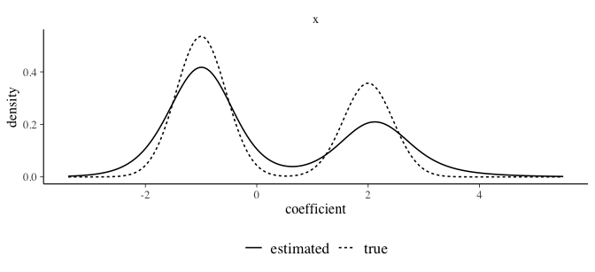

```r
plot(mixture, type = "mixture")
```

`latent_class_diagnostics()` returns the posterior distribution of the number of occupied classes, the membership probabilities of the deciders after relabeling, and the co-clustering matrix. Its entries are the posterior probabilities that two deciders belong to the same class:

```r
class_diagnostics <- latent_class_diagnostics(mixture)
class_diagnostics$occupancy
```

```
#>   n_classes probability
#> 1         1           0
#> 2         2           1
```

```r
class_diagnostics$membership[1:6, ]
```

```
#>      class_1      class_2
#> 1 0.99733333 0.0026666667
#> 2 0.01666667 0.9833333333
#> 3 0.98733333 0.0126666667
#> 4 0.02000000 0.9800000000
#> 5 0.99933333 0.0006666667
#> 6 0.99933333 0.0006666667
```

```r
class_diagnostics$co_clustering[1:6, 1:6]
```

```
#>            1          2          3          4          5          6
#> 1 1.00000000 0.01800000 0.98466667 0.02266667 0.99666667 0.99666667
#> 2 0.01800000 1.00000000 0.02933333 0.96466667 0.01733333 0.01600000
#> 3 0.98466667 0.02933333 1.00000000 0.03266667 0.98666667 0.98666667
#> 4 0.02266667 0.96466667 0.03266667 1.00000000 0.02066667 0.02066667
#> 5 0.99666667 0.01733333 0.98666667 0.02066667 1.00000000 0.99866667
#> 6 0.99666667 0.01600000 0.98666667 0.02066667 0.99866667 1.00000000
```

### Class-specific coefficients

Do the train travelers of the vignette [Get started with RprobitB](https://loelschlaeger.de/RprobitB/articles/v01_get_started.html) all trade time against money at the same rate, or are there classes with different values of time? The fit below uses the first 60 travelers, fixes the price coefficient to `-1`, and gives the time coefficient two class-specific values through `latent_class_effects` without a random effect, so each class has its own value of travel time and the remaining coefficients are common to both classes.

```r
data("Train", package = "mlogit")
Train$price_A <- Train$price_A / 100 / 2.20371
Train$price_B <- Train$price_B / 100 / 2.20371
Train$time_A <- Train$time_A / 60
Train$time_B <- Train$time_B / 60
train_small <- Train[Train$id %in% unique(Train$id)[1:60], ]
train_classes <- fit(
  choice ~ price + time + change + factor(comfort) | 0,
  data = train_small,
  latent_class_effects = "time",
  classes = 2,
  column_decider = "id",
  column_occasion = "choiceid",
  scale = c(price = -1),
  iterations = 1500,
  chains = 2,
  progress = FALSE
)
summary(train_classes, variables = c(
  "weight[1]", "weight[2]", "beta[time,1]", "beta[time,2]"
))
```

```
#> Bayesian probit choice model
#> Formula: choice ~ price + time + change + factor(comfort) | 0 | 0
#> Samples: 750 retained per chain, 2 chains
#>
#>      variable    mean    mode    sd rhat ess_bulk
#>     weight[1]   0.774   0.805 0.088 1.04     39.8
#>     weight[2]   0.226   0.195 0.088 1.04     39.8
#>  beta[time,1]  -2.939  -2.987 1.014 1.02     54.0
#>  beta[time,2] -20.951 -17.814 6.345 1.07     23.6
```

With the price coefficient fixed at `-1`, the class-specific time coefficients give the values of travel time in euro per hour, which `interpret()` reports class by class:

```r
time_by_class <- interpret(train_classes, effects = "time")
time_by_class
```

```
#> Class 1: 1 `time` compensates -2.94 `price` (95% interval -4.86 to -0.979)
#> Class 2: 1 `time` compensates -21 `price` (95% interval -39.2 to -12.9)
```

The larger class values an hour at about 3 euro, the smaller class at about 21 euro. The smaller class is willing to pay much more for a faster trip.

### Weight-based class updates

Oelschläger and Bauer (2021) presents a weight-based update scheme for latent class analysis. Every `buffer` warmup iterations, it removes the smallest class if its weight is below `epsmin`, splits the largest class if its weight is above `epsmax`, or merges the closest pair of classes if the distance of their means is below `deltamin`, at most one operation in this order. `weight_based_control` overrides the defaults of these constants, and `max_classes` bounds the splitting. These dimension changes correspond to no prior on the number of classes, and they stop after warmup, so the reported `n_classes` is the outcome of a search, not a posterior distribution.

This refit and the two in the following subsections change the class update, so `summary()` has no `dgp` column for them. The helper `recover_classes()` provides the comparison with the true values instead. The classes are numbered by decreasing weight, so the first class should be the majority with weight `0.6` and mean `-1`, and the second class the minority with weight `0.4` and mean `2`. The helper puts the posterior means of these four variables and the most probable number of occupied classes beside the true values. Applied to the fit with two fixed classes, it gives the reference for the refits:

```r
recover_classes <- function(x) {
  variables <- c("weight[1]", "weight[2]", "mu[x,1]", "mu[x,2]")
  occupancy <- latent_class_diagnostics(x)$occupancy
  data.frame(
    variable = c("n_classes", variables),
    dgp = c(2, 0.6, 0.4, -1, 2),
    estimate = round(c(
      occupancy$n_classes[which.max(occupancy$probability)],
      coef(x)[variables]
    ), 2),
    row.names = NULL
  )
}
recover_classes(mixture)
```

```
#>    variable  dgp estimate
#> 1 n_classes  2.0     2.00
#> 2 weight[1]  0.6     0.63
#> 3 weight[2]  0.4     0.37
#> 4   mu[x,1] -1.0    -1.02
#> 5   mu[x,2]  2.0     2.21
```

The weight-based refit is compared in the same way:

```r
weight_based <- update(mixture, class_update = "weight_based")
recover_classes(weight_based)
```

```
#>    variable  dgp estimate
#> 1 n_classes  2.0     3.00
#> 2 weight[1]  0.6     0.56
#> 3 weight[2]  0.4     0.34
#> 4   mu[x,1] -1.0    -1.05
#> 5   mu[x,2]  2.0     2.10
```

### Sparse finite mixtures

A sparse finite mixture fixes a generous upper bound $K$, permits empty classes, and places the symmetric Dirichlet prior with a small concentration $e_0$ on the weights, which favors emptying redundant classes (Rousseau and Mengersen 2011; Malsiner-Walli et al. 2016; Frühwirth-Schnatter and Malsiner-Walli 2019). The default `class_concentration = c(shape = 1, rate = 200)` is the gamma hyperprior $e_0\sim\operatorname{Gamma}(1,200)$ with mean `0.005`. Under a fixed $e_0$, the prior expected number of occupied classes among $N$ deciders is

$$K\left[1-
\frac{\Gamma(Ke_0)\,\Gamma((K-1)e_0+N)}
{\Gamma((K-1)e_0)\,\Gamma(Ke_0+N)}\right],$$

which translates $e_0$ into a statement about the number of classes. At the prior mean $e_0 = 0.005$, with $K = 6$ and the 100 deciders of the simulated data, the prior expects close to a single occupied class. The refit sets the upper bound to six classes for the two-class data.

```r
sparse <- update(mixture, classes = 6, class_update = "sparse")
summary(sparse)
```

```
#> Bayesian probit choice model
#> Formula: choice ~ x | 0 | 0
#> Samples: 750 retained per chain, 2 chains
#>
#>             variable occupied     mean     mode      sd rhat ess_bulk
#>            weight[1]  1.00000  0.62908  0.64227 0.06526 1.01    94.04
#>            weight[2]  1.00000  0.36687  0.35922 0.05822 1.01   109.80
#>            weight[3]  0.04000  0.08534  0.01388 0.11038   NA       NA
#>            weight[4]  0.01133  0.01544  0.01532 0.00821   NA       NA
#>            weight[5]  0.00467  0.01494  0.01830 0.00933   NA       NA
#>            weight[6]  0.00400  0.00697  0.00617 0.00385   NA       NA
#>              mu[x,1]  1.00000 -1.00645 -0.97995 0.13520 1.01    88.45
#>              mu[x,2]  1.00000  2.06013  2.07561 0.31076 1.05    30.80
#>              mu[x,3]  0.04000 -0.09706 -1.31657 1.94384   NA       NA
#>              mu[x,4]  0.01133 -0.03626  1.30928 1.70834   NA       NA
#>              mu[x,5]  0.00467  0.06371  1.68176 2.23943   NA       NA
#>              mu[x,6]  0.00400  1.08695  2.28391 1.57156   NA       NA
#>         Omega[x,x,1]  1.00000  0.37263  0.28415 0.15974 1.03    38.37
#>         Omega[x,x,2]  1.00000  0.34707  0.17466 0.31326 1.04    54.63
#>         Omega[x,x,3]  0.04000  0.42335  0.26093 0.40846   NA       NA
#>         Omega[x,x,4]  0.01133  0.61908  0.34972 0.44831   NA       NA
#>         Omega[x,x,5]  0.00467  0.69236  0.43262 0.44588   NA       NA
#>         Omega[x,x,6]  0.00400  0.63493  0.60184 0.45175   NA       NA
#>  class_concentration  1.00000  0.01044  0.00450 0.00828 1.17     8.94
#>            n_classes  1.00000  2.06000  2.00000 0.24312 1.07    28.58
```

```r
latent_class_diagnostics(sparse)$occupancy
```

```
#>   n_classes probability
#> 1         1 0.000000000
#> 2         2 0.941333333
#> 3         3 0.057333333
#> 4         4 0.001333333
#> 5         5 0.000000000
#> 6         6 0.000000000
```

```r
recover_classes(sparse)
```

```
#>    variable  dgp estimate
#> 1 n_classes  2.0     2.00
#> 2 weight[1]  0.6     0.63
#> 3 weight[2]  0.4     0.37
#> 4   mu[x,1] -1.0    -1.01
#> 5   mu[x,2]  2.0     2.06
```

Although the prior favors a single class, the posterior concentrates on two occupied classes, whose weights and means are close to the true values. When the number of classes varies, a class exists only in part of the draws, and the `occupied` column of `summary()` reports this share.

### Dirichlet-process mixtures

For `class_update = "dirichlet_process"`, the precision $\alpha$ controls the prior tendency to open new classes, with the default $\alpha\sim\operatorname{Gamma}(2,4)$ of mean `0.5`. Conditional on a fixed $\alpha$, the prior expects $\sum_{i=1}^{N}\alpha/(\alpha+i-1)$ occupied classes among $N$ deciders, which for $\alpha = 0.5$ and 100 deciders is about three. **RprobitB** updates $\alpha$ with the augmentation of Escobar and West (1995) and the allocations with the auxiliary-parameter algorithm of Neal (2000). `max_classes` caps the number of classes the sampler may open, and `fit()` warns when the draws reach the cap.

```r
dynamic <- update(
  mixture, class_update = "dirichlet_process", max_classes = 15,
  iterations = 1000
)
summary(dynamic)
```

```
#> Bayesian probit choice model
#> Formula: choice ~ x | 0 | 0
#> Samples: 500 retained per chain, 2 chains
#>
#>             variable occupied    mean    mode     sd rhat ess_bulk
#>            weight[1]    1.000  0.5327  0.6022 0.1077 1.11     14.4
#>            weight[2]    1.000  0.3375  0.3619 0.0763 1.05     40.5
#>            weight[3]    0.813  0.0744  0.0206 0.0660   NA       NA
#>            weight[4]    0.530  0.0724  0.0203 0.0788   NA       NA
#>            weight[5]    0.339  0.0536  0.0173 0.0603   NA       NA
#>            weight[6]    0.203  0.0450  0.0147 0.0499   NA       NA
#>            weight[7]    0.086  0.0293  0.0109 0.0311   NA       NA
#>            weight[8]    0.038  0.0263  0.0102 0.0295   NA       NA
#>            weight[9]    0.015  0.0100  0.0100 0.0000   NA       NA
#>           weight[10]    0.003  0.0100  0.0100 0.0000   NA       NA
#>           weight[11]    0.001  0.0200  0.0200     NA   NA       NA
#>              mu[x,1]    1.000 -1.0552 -1.0440 0.1760 1.02     94.6
#>              mu[x,2]    1.000  1.9232  1.7251 0.4086 1.02     39.3
#>              mu[x,3]    0.813 -0.6853 -1.1228 2.4706   NA       NA
#>              mu[x,4]    0.530 -0.1693 -0.8325 2.1575   NA       NA
#>              mu[x,5]    0.339 -0.3172  0.0500 2.2574   NA       NA
#>              mu[x,6]    0.203 -0.2479  1.5055 2.4782   NA       NA
#>              mu[x,7]    0.086 -0.3894 -0.1388 2.4836   NA       NA
#>              mu[x,8]    0.038  0.2574  2.5713 3.2928   NA       NA
#>              mu[x,9]    0.015 -0.8944  1.0435 3.0678   NA       NA
#>             mu[x,10]    0.003 -2.9824 -5.3082 4.0407   NA       NA
#>             mu[x,11]    0.001  0.2647  0.2647     NA   NA       NA
#>         Omega[x,x,1]    1.000  0.3239  0.2224 0.1798 1.10     17.1
#>         Omega[x,x,2]    1.000  0.5959  0.2310 0.5756 1.08     27.7
#>         Omega[x,x,3]    0.813  0.7379  0.2683 1.1778   NA       NA
#>         Omega[x,x,4]    0.530  0.8055  0.2880 1.0864   NA       NA
#>         Omega[x,x,5]    0.339  0.6804  0.2614 0.7954   NA       NA
#>         Omega[x,x,6]    0.203  0.8089  0.2642 1.7390   NA       NA
#>         Omega[x,x,7]    0.086  0.7110  0.3905 0.8671   NA       NA
#>         Omega[x,x,8]    0.038  1.0510  0.3937 1.1577   NA       NA
#>         Omega[x,x,9]    0.015  0.6780  0.3782 0.5460   NA       NA
#>        Omega[x,x,10]    0.003  0.8921  1.1802 0.6017   NA       NA
#>        Omega[x,x,11]    0.001  0.6880  0.6880     NA   NA       NA
#>  class_concentration    1.000  0.5929  0.3731 0.3479 1.02     61.7
#>            n_classes    1.000  4.0280  3.0000 1.6906 1.07     20.4
```

```r
latent_class_diagnostics(dynamic)$occupancy
```

```
#>    n_classes probability
#> 1          1       0.000
#> 2          2       0.187
#> 3          3       0.283
#> 4          4       0.191
#> 5          5       0.136
#> 6          6       0.117
#> 7          7       0.048
#> 8          8       0.023
#> 9          9       0.012
#> 10        10       0.002
#> 11        11       0.001
#> 12        12       0.000
#> 13        13       0.000
#> 14        14       0.000
#> 15        15       0.000
```

```r
recover_classes(dynamic)
```

```
#>    variable  dgp estimate
#> 1 n_classes  2.0     3.00
#> 2 weight[1]  0.6     0.53
#> 3 weight[2]  0.4     0.34
#> 4   mu[x,1] -1.0    -1.06
#> 5   mu[x,2]  2.0     1.92
```

The occupancy distribution is wider than under the sparse finite prior and assigns most of its probability to three or more classes. This reflects the prior, which expects about three occupied classes for 100 deciders. The two largest classes nevertheless resemble the two true groups, because the superfluous classes contain only a few deciders.

The estimated mixing distributions of the three refits also show the two groups that generated the data:

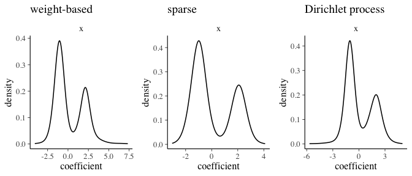

```r
bayesplot::bayesplot_grid(
  plot(weight_based, type = "mixture"),
  plot(sparse, type = "mixture"),
  plot(dynamic, type = "mixture"),
  titles = c("weight-based", "sparse", "Dirichlet process"),
  grid_args = list(nrow = 1)
)
```

## Ordered and ranked responses

Both mechanisms also work for ordered and ranked responses, which the vignette [Model specification and variants](https://loelschlaeger.de/RprobitB/articles/v02_model_variants.html) introduces. The following demonstration uses a simulated panel of rankings: 100 deciders order three alternatives five times each, with a coefficient that varies normally around `-1`.

```r
ranked_random <- fit(
  rank ~ x | 0,
  choice_type = "ranked",
  random_effects = "x",
  n_deciders = 100,
  n_occasions = 5,
  n_alternatives = 3,
  dgp_parameters = list(beta = c(x = -1), Omega = matrix(0.3)),
  iterations = 2000,
  chains = 1,
  progress = FALSE
)
summary(ranked_random)
```

```
#> Bayesian probit choice model
#> Formula: rank ~ x | 0 | 0
#> Samples: 1000 retained per chain, 1 chain
#>    variable    dgp   mean   mode     sd rhat ess_bulk
#>       mu[x] -1.000 -0.923 -0.912 0.0667 1.05     17.6
#>  Omega[x,x]  0.300  0.245  0.232 0.0532 1.07     14.6
#>  Sigma[B,C]  0.246  0.217  0.238 0.0398 1.03     43.6
#>  Sigma[C,C]  0.163  0.136  0.112 0.0355 1.01     41.4
```

The summary shows the population mean and variance beside their true values. Ordered responses accept the same arguments, and latent classes are requested in the same way as above, with `latent_class_effects` and `classes`.

## Further reading

The vignette [Posterior prediction](https://loelschlaeger.de/RprobitB/articles/v04_prediction.html) uses the individual coefficients to compute choice probabilities for each decider in the fit. The vignette [Bayesian model evaluation](https://loelschlaeger.de/RprobitB/articles/v05_model_evaluation.html) shows how to decide whether random coefficients improve a model.

## References

Allenby, Greg M., and Peter E. Rossi. 1998. “Marketing Models of Consumer Heterogeneity.” *Journal of Econometrics* 89 (1-2): 57–78. https://doi.org/10.1016/S0304-4076(98)00055-4.

Croissant, Yves. 2020. “Estimation of Random Utility Models in R: The mlogit Package.” *Journal of Statistical Software* 95 (11): 1–41. https://doi.org/10.18637/jss.v095.i11.

Dahl, David B. 2006. “Model-Based Clustering for Expression Data via a Dirichlet Process Mixture Model.” In *Bayesian Inference for Gene Expression and Proteomics*, edited by Kim-Anh Do, Peter Müller, and Marina Vannucci. Cambridge University Press. https://doi.org/10.1017/CBO9780511584589.011.

Escobar, Michael D., and Mike West. 1995. “Bayesian Density Estimation and Inference Using Mixtures.” *Journal of the American Statistical Association* 90 (430): 577–88. https://doi.org/10.1080/01621459.1995.10476550.

Frühwirth-Schnatter, Sylvia, and Gertraud Malsiner-Walli. 2019. “From Here to Infinity: Sparse Finite Versus Dirichlet Process Mixtures in Model-Based Clustering.” *Advances in Data Analysis and Classification* 13 (1): 33–64. https://doi.org/10.1007/s11634-018-0329-y.

Greene, William H., and David A. Hensher. 2003. “A Latent Class Model for Discrete Choice Analysis: Contrasts with Mixed Logit.” *Transportation Research Part B: Methodological* 37 (8): 681–98. https://doi.org/10.1016/S0191-2615(02)00046-2.

Huber, Joel, and Kenneth Train. 2001. “On the Similarity of Classical and Bayesian Estimates of Individual Mean Partworths.” *Marketing Letters* 12 (3): 259–69. https://doi.org/10.1023/A:1011120928698.

Kamakura, Wagner A., and Gary J. Russell. 1989. “A Probabilistic Choice Model for Market Segmentation and Elasticity Structure.” *Journal of Marketing Research* 26 (4): 379–90.

Malsiner-Walli, Gertraud, Sylvia Frühwirth-Schnatter, and Bettina Grün. 2016. “Model-Based Clustering Based on Sparse Finite Gaussian Mixtures.” *Statistics and Computing* 26 (1–2): 303–24. https://doi.org/10.1007/s11222-014-9500-2.

Neal, Radford M. 2000. “Markov Chain Sampling Methods for Dirichlet Process Mixture Models.” *Journal of Computational and Graphical Statistics* 9 (2): 249–65. https://doi.org/10.1080/10618600.2000.10474879.

Oelschläger, Lennart. 2026. “Overcoming Challenges in Modeling Choice Behavior Heterogeneity.” PhD thesis, Bielefeld University. https://pub.uni-bielefeld.de/record/3014719.

Oelschläger, Lennart, and Dietmar Bauer. 2021. “Bayes Estimation of Latent Class Mixed Multinomial Probit Models.” *Proceedings of the 100th Annual Meeting of the Transportation Research Board* (Washington, DC). https://trid.trb.org/view/1759753.

Papastamoulis, Panagiotis, and George Iliopoulos. 2010. “An Artificial Allocations Based Solution to the Label Switching Problem in Bayesian Analysis of Mixtures of Distributions.” *Journal of Computational and Graphical Statistics* 19 (2): 313–31. https://doi.org/10.1198/jcgs.2010.09008.

Rousseau, Judith, and Kerrie Mengersen. 2011. “Asymptotic Behaviour of the Posterior Distribution in Overfitted Mixture Models.” *Journal of the Royal Statistical Society: Series B (Statistical Methodology)* 73 (5): 689–710. https://doi.org/10.1111/j.1467-9868.2011.00781.x.